# week3_exercise

## Task 4: Segment-based analysis

# Assign unique ID for each segment, that we can use as grouping variable

```r
rle_id <- function(vec){
  x <- rle(vec)$lengths
  as.factor(rep(seq_along(x), times=x))
  }
#rle_id ist Name der Funktion, alles danach ist das was diese tut
```

#Use function to assign unique IDs to subtrajectories.

```r
caro <- caro %>%
  mutate(segment_id = rle_id(static))
```

#Visualize moving segments by colourizing them by segment_ID.

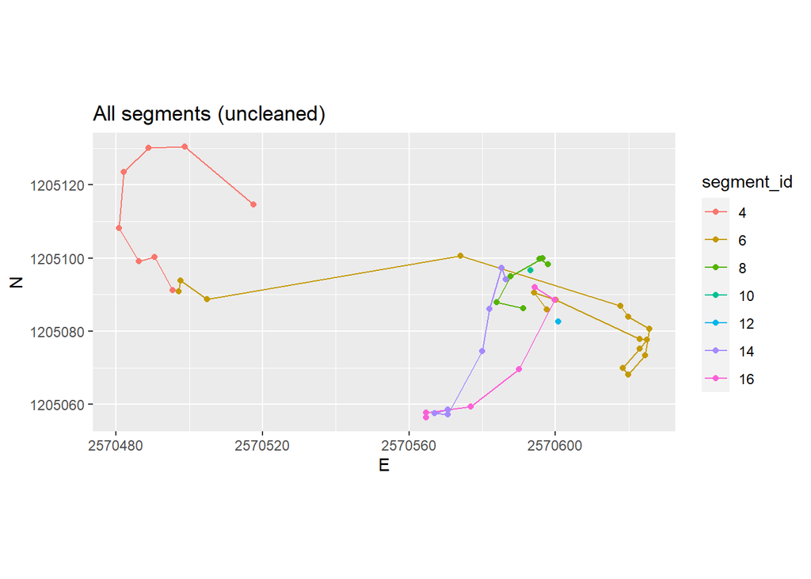

```r
caro %>%
  filter(static == FALSE) %>%   #Filter, damit nur Segmente in denen sich etwas bewegt, gezeigt werden; im Beispiel stand "filter(!static)" --> umgeschrieben um doppelte Verneinung zu vermeiden
  ggplot(aes(E, N, color=segment_id))+
  geom_path()+
  geom_point()+
  coord_equal()+
  labs(title = "All segments (uncleaned)")
```

#Use segment_ID as a grouping variable to determine the segments duration and remove short segments (e.g. segments with a duration < 5 Minutes)

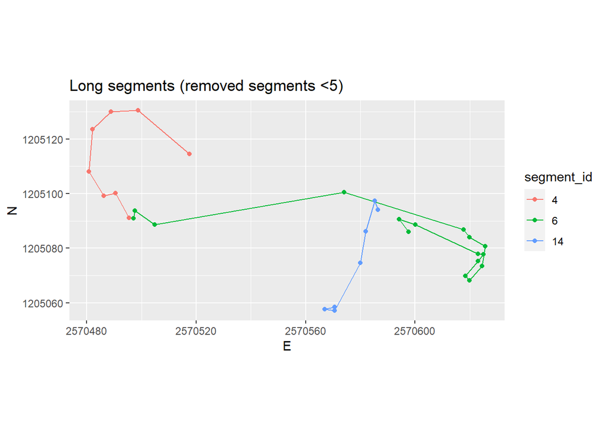

```r
caro_cleaned <- caro %>%
  group_by(segment_id) %>%
  mutate(duration = max(DatetimeUTC)-min(DatetimeUTC))%>% #berechne Dauer der Bewegung
  filter(duration > 300)%>%  #entferne alle Segmente mit Bewegung < 5 Minuten
  filter(static == FALSE)   #entferne alle "unbeweglichen" Punkte (hätte man sicher auch schon oben machen können)

ggplot(caro_cleaned, aes(E, N, color = segment_id))+
  geom_path()+
  geom_point()+
  coord_equal()+
  labs(title = "Long segments (removed segments <5)")
```

```r
#gleicht Grafik in Beispiel, aber hat noch mehr Segmente, vermutlich Threshold zu klein gewählt
```

## Task 5: Similarity measures on human movement

# Achtung neues Dataset

```r
pedestrian <- read_delim("pedestrian.csv",",")
```

#Explore the trajectories first and get an idea on how the pedestrians moved

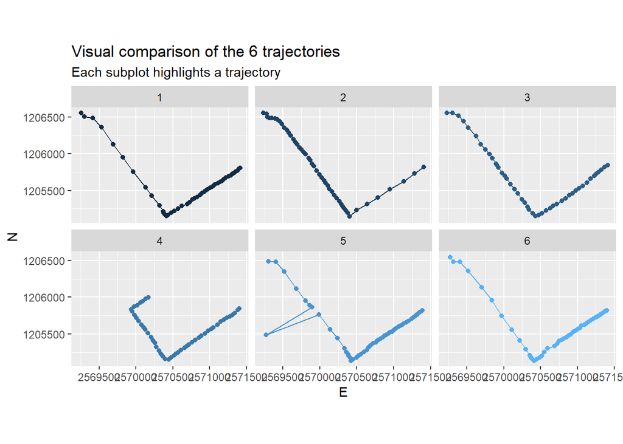

```r
ggplot(pedestrian, aes(E, N, color = TrajID))+
  geom_path()+
  geom_point()+
  coord_equal()+
  theme(legend.position = "none")+
  labs(title = "Visual comparison of the 6 trajectories",
      subtitle = "Each subplot highlights a trajectory")+
  facet_wrap(~ TrajID)
```

## Task 6: Calculate similarity

#Install package SimilarityMeasures

```r
#install.packages("SimilarityMeasures")
#am Anfang Datei ausgeführt
```

#Get familiar with the package

```r
?SimilarityMeasures
```

```
## starting httpd help server ... done
```

#All functions in the package need matrices as input, with one trajectory per matrix.

```r
#Select and safe single trajectories
TJ1 <- pedestrian %>%
  filter(TrajID == 1)
TJ2 <- pedestrian %>%
  filter(TrajID == 2)
TJ3 <- pedestrian %>%
  filter(TrajID == 3)
TJ4 <- pedestrian %>%
  filter(TrajID == 4)
TJ5 <- pedestrian %>%
  filter(TrajID == 5)
TJ6 <- pedestrian %>%
  filter(TrajID == 6)

#Change from dataframe to matrix
TJ1_mtx <- data.matrix(TJ1)
TJ2_mtx <- data.matrix(TJ2)
TJ3_mtx <- data.matrix(TJ3)
TJ4_mtx <- data.matrix(TJ4)
TJ5_mtx <- data.matrix(TJ5)
TJ6_mtx <- data.matrix(TJ6)
```

# Calculate DTW (dynamic time warping)

```r
#DTW(traj1, traj2, pointSpacing=-1)
#point spacing: integer value of the maximum index difference between trajectory1 and trajectory2 allowed in the calculation. A negative value sets the point spacing to unlimited.
TJ2_dtw <- DTW(TJ1_mtx, TJ2_mtx, pointSpacing = 4)
TJ3_dtw <- DTW(TJ1_mtx, TJ3_mtx, pointSpacing = 4)
TJ4_dtw <- DTW(TJ1_mtx, TJ4_mtx, pointSpacing = 4)
TJ5_dtw <- DTW(TJ1_mtx, TJ5_mtx, pointSpacing = 4)
TJ6_dtw <- DTW(TJ1_mtx, TJ6_mtx, pointSpacing = 4)
```

#Calculate Edit Distance

```r
#EditDist(traj1, traj2, pointDistance=20)
#point distance: floating point number representing maximum distance in each dimension allowed for points to be considered equivalent.
TJ2_editdist <- EditDist(TJ1_mtx, TJ2_mtx, pointDistance = 4)
TJ3_editdist <- EditDist(TJ1_mtx, TJ3_mtx, pointDistance = 4)
TJ4_editdist <- EditDist(TJ1_mtx, TJ4_mtx, pointDistance = 4)
TJ5_editdist <- EditDist(TJ1_mtx, TJ5_mtx, pointDistance = 4)
TJ6_editdist <- EditDist(TJ1_mtx, TJ6_mtx, pointDistance = 4)
```

#Calculate Frechet

```r
#Frechet(traj1, traj2, testLeash=-1)
#testleash: numeric value, which if positive, checks whether the leash can be used --> results in boolean; if values negative, then it is not used and the standard calculation is performed.
TJ2_frechet <- Frechet(TJ1_mtx, TJ2_mtx, testLeash = -1)
TJ3_frechet <- Frechet(TJ1_mtx, TJ3_mtx, testLeash = -1)
TJ4_frechet <- Frechet(TJ1_mtx, TJ4_mtx, testLeash = -1)
TJ5_frechet <- Frechet(TJ1_mtx, TJ5_mtx, testLeash = -1)
TJ6_frechet <- Frechet(TJ1_mtx, TJ6_mtx, testLeash = -1)
```

#Calculate LCSS (allowing translations)

```r
#LCSS(traj1, traj2, pointSpacing=-1, pointDistance=20, errorMarg=2, returnTrans=FALSE)
#pointSpacing: integer value of the maximum index difference between trajectory1 and trajectory2 allowed in the calculation. A negative value sets the point spacing to unlimited.
# pointDistance: floating point number representing the maximum distance in each dimension allowed for points to be considered equivalent.
#errorMarg: floating point error margin used to scale the accuracy and speed of the calculation.
#returnTrans: boolean value to allow the best translation found to be returned as well as the LCSS value if set to true
TJ2_lcss <- LCSS(TJ1_mtx, TJ2_mtx, pointSpacing = 4, pointDistance = 4, errorMarg = 2, returnTrans = FALSE)
TJ3_lcss <- LCSS(TJ1_mtx, TJ3_mtx, pointSpacing = 4, pointDistance = 4, errorMarg = 2, returnTrans = FALSE)
TJ4_lcss <- LCSS(TJ1_mtx, TJ4_mtx, pointSpacing = 4, pointDistance = 4, errorMarg = 2, returnTrans = FALSE)
TJ5_lcss <- LCSS(TJ1_mtx, TJ5_mtx, pointSpacing = 4, pointDistance = 4, errorMarg = 2, returnTrans = FALSE)
TJ6_lcss <- LCSS(TJ1_mtx, TJ6_mtx, pointSpacing = 4, pointDistance = 4, errorMarg = 2, returnTrans = FALSE)
```

#Create Tibble/Dataframe from calculated values

```r
#Zusammenfügen aller errechneten Werte pro Measure Methode

#Option 1: Dataframe
#würde theoretische funktionieren, aber teilweise nicht nachvollziehbare Values und Fehlermeldungen
#Traj_all <- data.frame(
#       "dtw" = c(TJ2_dtw,TJ3_dtw,TJ4_dtw,TJ5_dtw,TJ6_dtw),
#       "editdist"= c(TJ2_editdist,TJ3_editdist,TJ4_editdist,TJ5_editdist,TJ6_editdist),
#       "frechet" = c(TJ2_frechet,TJ3_frechet,TJ4_frechet,TJ5_frechet,TJ6_frechet),
#       "lcss" = c(TJ2_lcss,TJ3_lcss,TJ4_lcss,TJ5_lcss,TJ6_lcss),
#       "trajectory" = c(2,3,4,5,6))


#Option 2: Tibble
dtw <- c(TJ2_dtw, TJ3_dtw, TJ4_dtw, TJ5_dtw, TJ6_dtw)
editdist <- c(TJ2_editdist, TJ3_editdist, TJ4_editdist, TJ5_editdist, TJ6_editdist)
frechet <- c(TJ2_frechet, TJ3_frechet, TJ4_frechet, TJ5_frechet, TJ6_frechet)
lcss <- c(TJ2_lcss, TJ3_lcss, TJ4_lcss, TJ5_lcss, TJ6_lcss)

Traj_all <- tibble(dtw, editdist, frechet, lcss, trajectory = c(2,3,4,5,6))

#Umformen des Tibbles (oder Dataframes)
Traj_long <- Traj_all %>%
  pivot_longer(names_to = "name", values_to = "value", -trajectory)
```

#Visualize and compare Traj1 to Traj2-6 using different similarity measures

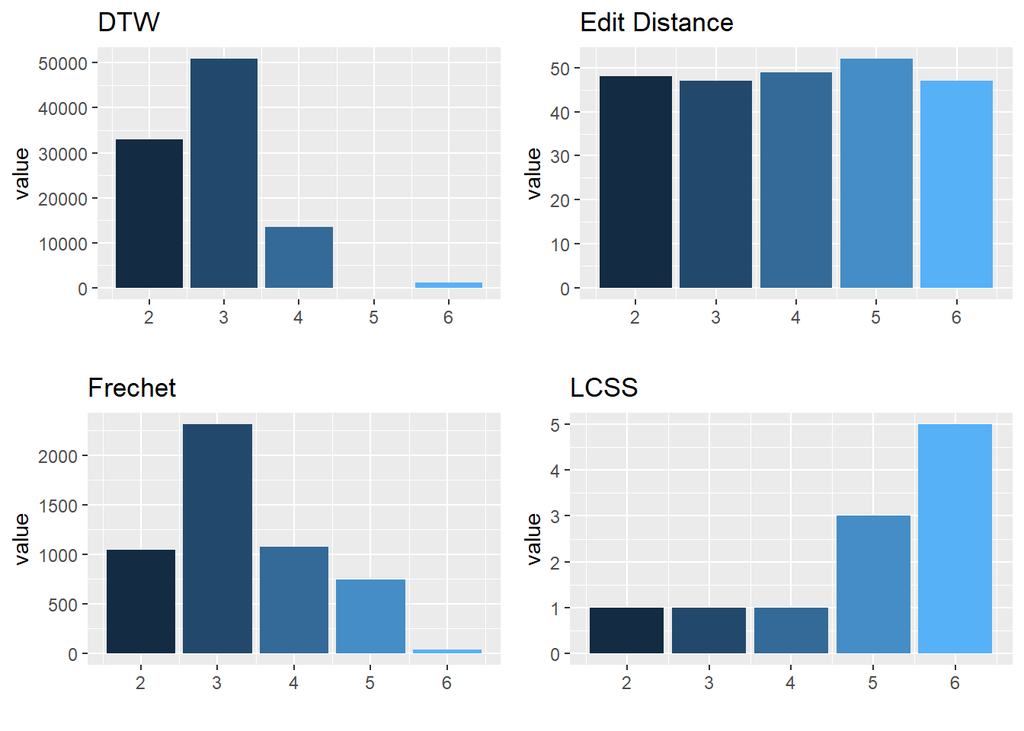

```r
#Prepare single plots for each measure method
dtw_plot <- Traj_long %>%
  filter(name == "dtw") %>%
  ggplot()+
  theme(legend.position = "none")+
  labs(x="",title = "DTW")+
  geom_col(mapping = aes(x = trajectory, y = value, fill = trajectory))

editdist_plot <- Traj_long %>%
  filter(name == "editdist") %>%
  ggplot()+
  theme(legend.position = "none")+
  labs(x="",title = "Edit Distance")+
  geom_col(mapping = aes(x = trajectory, y = value, fill = trajectory))

frechet_plot <- Traj_long %>%
  filter(name == "frechet") %>%
  ggplot()+
  theme(legend.position = "none")+
  labs(x="",title = "Frechet")+
  geom_col(mapping = aes(x = trajectory, y = value, fill = trajectory))

lcss_plot <- Traj_long %>%
  filter(name == "lcss") %>%
  ggplot()+
  theme(legend.position = "none")+
  labs(x="",title = "LCSS")+
  geom_col(mapping = aes(x = trajectory, y = value, fill = trajectory))

#Zusammenfügen aller Plots
plot_grid(dtw_plot, editdist_plot, frechet_plot, lcss_plot)
```

```r
#könnte noch Legende und Überschrift vertragen
#Grafiken DTW und LCSS sehen anders aus als Beispiel
```